# ch02_01_02_linear_boston_evaluation_v11

## ch03 선형모델 - linear model

### 학습 목표

- 선형 모델(Linear Regression)에 대해 이해합니다.
  - 보스턴 집값 데이터 셋을 활용하여 회귀 모델을 만들어 봅니다.

### 학습 내용

- Boston 데이터 셋 불러오기
- 집값 예측 선형모델 구축
- 모델 평가 지표 알아보기
  - MAE
  - MSE
  - RMSE
  - RMLSE
  - MAPE

### 목차

01 matplotlib의 한글 폰트 설정  
02 Boston 데이터 셋을 활용한 회귀 모델 만들어보기  
03 회귀의 평가지표 알아보기  
04 회귀의 평가지표 구하기

```python
from IPython.display import display, Image
```

### 01 matplotlib의 한글 폰트 설정

목차로 이동하기

```python
### 한글 폰트 설정
import matplotlib
from matplotlib import font_manager, rc
import matplotlib.pyplot as plt
import platform

path = "C:/Windows/Fonts/malgun.ttf"
if platform.system() == "Windows":
    font_name = font_manager.FontProperties(fname=path).get_name()
    rc('font', family=font_name)
elif platform.system()=="Darwin":
    rc('font', family='AppleGothic')
else:
    print("Unknown System")

matplotlib.rcParams['axes.unicode_minus'] = False
%matplotlib inline
```

```python
import numpy as np
import matplotlib.pyplot as plt
import matplotlib

print("numpy 버전 : ", np.__version__)
print("matplotlib 버전 : ", matplotlib.__version__)

# 설치가 안되어 있을 경우, 설치 필요.
import mglearn
import sklearn

print("sklearn 버전 : ",  sklearn.__version__)
print("mglearn 버전 : ",  mglearn.__version__)

from sklearn.model_selection import train_test_split
from sklearn.linear_model import LinearRegression
```

```
numpy 버전 :  1.21.5
matplotlib 버전 :  3.5.1
sklearn 버전 :  1.0.2
mglearn 버전 :  0.1.9
```

### 02 Boston 데이터 셋을 활용한 회귀 모델 만들어보기

목차로 이동하기

### 데이터 설명

- 1970년대의 보스턴 주변의 주택 평균 가격 예측
- 506개의 데이터 포인트와 13개의 특성

```
(1) 모델 만들기 [  모델명 = 모델객체() ]
(2) 모델 학습 시키기 [ 모델명.fit() ]
(3) 모델을 활용한 예측하기 [ 모델명.predict() ]
(4) 모델 평가
```

```python
from sklearn.linear_model import LinearRegression
from sklearn.datasets import load_boston
import pandas as pd
```

### 데이터 불러오기 2가지 방법

```python
# sklearn 이용
boston = load_boston()
X = boston.data       # 입력 데이터  - 문제
y = boston.target     # 출력 데이터  - 답
```

[output not shown]

```python
# 판다스 이용
data_url = "http://lib.stat.cmu.edu/datasets/boston"
raw_df = pd.read_csv(data_url, sep="\s+", skiprows=22, header=None)
data = np.hstack([raw_df.values[::2, :], raw_df.values[1::2, :2]])
target = raw_df.values[1::2, 2]
X = data       # 입력 데이터  - 문제
y = target     # 출력 데이터  - 답

X.shape, y.shape
```

```
((506, 13), (506,))
```

### 데이터 살펴보기

| features | 내용 | 값 |  |
| --- | --- | --- | --- |
| crim | 마을별 1인당 범죄율 | - |  |
| zn | 25,000 평방 피트 이상의 대형 주택이 차지하는 주거용 토지의 비율 | - |  |
| indus | 소매상 이외의 상업 지구의 면적 비율 | - |  |
| chas | Charles River(찰스강 접한 지역인지 아닌지) (강 경계면=1, 아니면=0 | - |  |
| nox | 산화 질소 오염도(1000만분 율) | - |  |
| rm | 주거 당 평균 방수 | - |  |
| age | 1940년 이전에 지어진 소유주 집들의 비율 | - |  |
| dis | 보스턴 고용 센터 5곳까지의 가중 거리 | - |  |
| rad | 도시 순환 고속도로에의 접근 용이 지수 | - |  |
| tax | 만 달러당 주택 재산세율 | - |  |
| ptratio | 학생 - 선생 비율 | - |  |
| black-(B) | 흑인 인구 비율(Bk)이 지역 평균인 0.63과 다른 정도의 제곱 | - |  |
| lstat | 저소득 주민들의 비율 퍼센트 | - |  |
| (target) MEDV | 소유주가 거주하는 주택의 중간 가치($ 1000) | - |  |

```python
print( boston.keys() )
print( boston.feature_names )
```

```
dict_keys(['data', 'target', 'feature_names', 'DESCR', 'filename', 'data_module'])
['CRIM' 'ZN' 'INDUS' 'CHAS' 'NOX' 'RM' 'AGE' 'DIS' 'RAD' 'TAX' 'PTRATIO'
 'B' 'LSTAT']
```

### 주택 가격 - 히스토 그램

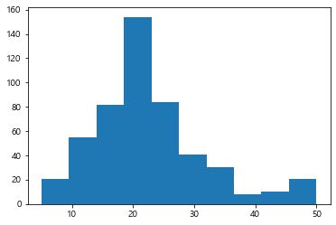

```python
plt.hist(y)
```

- (실습) DataFrame으로 만들어 기본 시각화 등을 통해 확인해 보자.

### 데이터 나누기 - 학습, 평가

```python
X_train, X_test, y_train, y_test = train_test_split(X, y,
                                           test_size=0.3,
                                           random_state=42)
```

```python
model = LinearRegression().fit(X_train, y_train)   # 학습
pred = model.predict(X_test)
pred
```

```
array([28.64896005, 36.49501384, 15.4111932 , 25.40321303, 18.85527988,
       23.14668944, 17.3921241 , 14.07859899, 23.03692679, 20.59943345,
       24.82286159, 18.53057049, -6.86543527, 21.80172334, 19.22571177,
       26.19191985, 20.27733882,  5.61596432, 40.44887974, 17.57695918,
       27.44319095, 30.1715964 , 10.94055823, 24.02083139, 18.07693812,
       15.934748  , 23.12614028, 14.56052142, 22.33482544, 19.3257627 ,
       22.16564973, 25.19476081, 25.31372473, 18.51345025, 16.6223286 ,
       17.50268505, 30.94992991, 20.19201752, 23.90440431, 24.86975466,
       13.93767876, 31.82504715, 42.56978796, 17.62323805, 27.01963242,
       17.19006621, 13.80594006, 26.10356557, 20.31516118, 30.08649576,
       21.3124053 , 34.15739602, 15.60444981, 26.11247588, 39.31613646,
       22.99282065, 18.95764781, 33.05555669, 24.85114223, 12.91729352,
       22.68101452, 30.80336295, 31.63522027, 16.29833689, 21.07379993,
       16.57699669, 20.36362023, 26.15615896, 31.06833034, 11.98679953,
       20.42550472, 27.55676301, 10.94316981, 16.82660609, 23.92909733,
        5.28065815, 21.43504661, 41.33684993, 18.22211675,  9.48269245,
       21.19857446, 12.95001331, 21.64822797,  9.3845568 , 23.06060014,
       31.95762512, 19.16662892, 25.59942257, 29.35043558, 20.13138581,
       25.57297369,  5.42970803, 20.23169356, 15.1949595 , 14.03241742,
       20.91078077, 24.82249135, -0.47712079, 13.70520524, 15.69525576,
       22.06972676, 24.64152943, 10.7382866 , 19.68622564, 23.63678009,
       12.07974981, 18.47894211, 25.52713393, 20.93461307, 24.6955941 ,
        7.59054562, 19.01046053, 21.9444339 , 27.22319977, 32.18608828,
       15.27826455, 34.39190421, 12.96314168, 21.01681316, 28.57880911,
       15.86300844, 24.85124135,  3.37937111, 23.90465773, 25.81792146,
       23.11020547, 25.33489201, 33.35545176, 20.60724498, 38.4772665 ,
       13.97398533, 25.21923987, 17.80946626, 20.63437371,  9.80267398,
       21.07953576, 22.3378417 , 32.32381854, 31.48694863, 15.46621287,
       16.86242766, 28.99330526, 24.95467894, 16.73633557,  6.12858395,
       26.65990044, 23.34007187, 17.40367164, 13.38594123, 39.98342478,
       16.68286302, 18.28561759])
```

### 예측값이 0이하의 값이 있다. 이 경우 RMLSE에서 에러 발생. pred를 0이하는 0으로 처리한다.

```python
type(pred)
```

```
numpy.ndarray
```

```python
pred[ pred < 0] = 0
pred
```

```
array([28.64896005, 36.49501384, 15.4111932 , 25.40321303, 18.85527988,
       23.14668944, 17.3921241 , 14.07859899, 23.03692679, 20.59943345,
       24.82286159, 18.53057049,  0.        , 21.80172334, 19.22571177,
       26.19191985, 20.27733882,  5.61596432, 40.44887974, 17.57695918,
       27.44319095, 30.1715964 , 10.94055823, 24.02083139, 18.07693812,
       15.934748  , 23.12614028, 14.56052142, 22.33482544, 19.3257627 ,
       22.16564973, 25.19476081, 25.31372473, 18.51345025, 16.6223286 ,
       17.50268505, 30.94992991, 20.19201752, 23.90440431, 24.86975466,
       13.93767876, 31.82504715, 42.56978796, 17.62323805, 27.01963242,
       17.19006621, 13.80594006, 26.10356557, 20.31516118, 30.08649576,
       21.3124053 , 34.15739602, 15.60444981, 26.11247588, 39.31613646,
       22.99282065, 18.95764781, 33.05555669, 24.85114223, 12.91729352,
       22.68101452, 30.80336295, 31.63522027, 16.29833689, 21.07379993,
       16.57699669, 20.36362023, 26.15615896, 31.06833034, 11.98679953,
       20.42550472, 27.55676301, 10.94316981, 16.82660609, 23.92909733,
        5.28065815, 21.43504661, 41.33684993, 18.22211675,  9.48269245,
       21.19857446, 12.95001331, 21.64822797,  9.3845568 , 23.06060014,
       31.95762512, 19.16662892, 25.59942257, 29.35043558, 20.13138581,
       25.57297369,  5.42970803, 20.23169356, 15.1949595 , 14.03241742,
       20.91078077, 24.82249135,  0.        , 13.70520524, 15.69525576,
       22.06972676, 24.64152943, 10.7382866 , 19.68622564, 23.63678009,
       12.07974981, 18.47894211, 25.52713393, 20.93461307, 24.6955941 ,
        7.59054562, 19.01046053, 21.9444339 , 27.22319977, 32.18608828,
       15.27826455, 34.39190421, 12.96314168, 21.01681316, 28.57880911,
       15.86300844, 24.85124135,  3.37937111, 23.90465773, 25.81792146,
       23.11020547, 25.33489201, 33.35545176, 20.60724498, 38.4772665 ,
       13.97398533, 25.21923987, 17.80946626, 20.63437371,  9.80267398,
       21.07953576, 22.3378417 , 32.32381854, 31.48694863, 15.46621287,
       16.86242766, 28.99330526, 24.95467894, 16.73633557,  6.12858395,
       26.65990044, 23.34007187, 17.40367164, 13.38594123, 39.98342478,
       16.68286302, 18.28561759])
```

### 03 회귀의 평가지표 알아보기

목차로 이동하기

```python
import pandas as pd
import numpy as np
```

```python
error = y_test - pred
error2 = (y_test - pred)**2

dict_dat = {"실제값":y_test, "예측값":pred, "오차":error, "오차제곱":error2}
dat = pd.DataFrame(dict_dat )
dat
```

|  | 실제값 | 예측값 | 오차 | 오차제곱 |
| --- | --- | --- | --- | --- |
| 0 | 23.6 | 28.648960 | -5.048960 | 25.491998 |
| 1 | 32.4 | 36.495014 | -4.095014 | 16.769138 |
| 2 | 13.6 | 15.411193 | -1.811193 | 3.280421 |
| 3 | 22.8 | 25.403213 | -2.603213 | 6.776718 |
| 4 | 16.1 | 18.855280 | -2.755280 | 7.591567 |
| ... | ... | ... | ... | ... |
| 147 | 17.1 | 17.403672 | -0.303672 | 0.092216 |
| 148 | 14.5 | 13.385941 | 1.114059 | 1.241127 |
| 149 | 50.0 | 39.983425 | 10.016575 | 100.331779 |
| 150 | 14.3 | 16.682863 | -2.382863 | 5.678036 |
| 151 | 12.6 | 18.285618 | -5.685618 | 32.326247 |

152 rows × 4 columns

```python
dat['오차절대값'] = abs(dat['오차'])
dat
```

|  | 실제값 | 예측값 | 오차 | 오차제곱 | 오차절대값 |
| --- | --- | --- | --- | --- | --- |
| 0 | 23.6 | 28.648960 | -5.048960 | 25.491998 | 5.048960 |
| 1 | 32.4 | 36.495014 | -4.095014 | 16.769138 | 4.095014 |
| 2 | 13.6 | 15.411193 | -1.811193 | 3.280421 | 1.811193 |
| 3 | 22.8 | 25.403213 | -2.603213 | 6.776718 | 2.603213 |
| 4 | 16.1 | 18.855280 | -2.755280 | 7.591567 | 2.755280 |
| ... | ... | ... | ... | ... | ... |
| 147 | 17.1 | 17.403672 | -0.303672 | 0.092216 | 0.303672 |
| 148 | 14.5 | 13.385941 | 1.114059 | 1.241127 | 1.114059 |
| 149 | 50.0 | 39.983425 | 10.016575 | 100.331779 | 10.016575 |
| 150 | 14.3 | 16.682863 | -2.382863 | 5.678036 | 2.382863 |
| 151 | 12.6 | 18.285618 | -5.685618 | 32.326247 | 5.685618 |

152 rows × 5 columns

### 평가 지표

- 모델을 평가하기 위해 회귀모델은 일반적으로 사용하는 지표는 다음을 사용합니다.
  - MAE(mean absolute error) : 평균 절대값 오차
  - MAPE(mean absolute percentage error) : 평균 절대값 백분율 오차
  - MSE(mean squared error) : 평균 제곱 오차
  - RMSE(root mean squared error) : 평균 제곱근 오차
  - RMLSE(Root Mean Squared Logarithmic Error)

```python
### MAE (mean absolute error)
mae_val = dat['오차절대값'].sum() / dat.shape[0]
mae_val
```

```
3.1144035815868536
```

```python
### MSE (mean squared error)
mse_val = dat['오차제곱'].sum() / dat.shape[0]
mse_val
```

```
20.46113591690506
```

```python
### RMSE(Root Mean Squared Error)
rmse_val = np.sqrt(mse_val)
rmse_val
```

```
4.523398713014923
```

### (실습) RMLSE 값을 구해보자.

```python
dat['실제값_log'] = np.log( dat['실제값'] + 1  )
dat['예측값_log'] = np.log( dat['예측값'] + 1  )
dat['log오차제곱'] = (dat['실제값_log'] - dat['예측값_log']) ** 2
```

```python
dat
```

|  | 실제값 | 예측값 | 오차 | 오차제곱 | 오차절대값 | 실제값_log | 예측값_log | log오차제곱 |
| --- | --- | --- | --- | --- | --- | --- | --- | --- |
| 0 | 23.6 | 28.648960 | -5.048960 | 25.491998 | 5.048960 | 3.202746 | 3.389427 | 0.034850 |
| 1 | 32.4 | 36.495014 | -4.095014 | 16.769138 | 4.095014 | 3.508556 | 3.624208 | 0.013375 |
| 2 | 13.6 | 15.411193 | -1.811193 | 3.280421 | 1.811193 | 2.681022 | 2.797964 | 0.013675 |
| 3 | 22.8 | 25.403213 | -2.603213 | 6.776718 | 2.603213 | 3.169686 | 3.273486 | 0.010774 |
| 4 | 16.1 | 18.855280 | -2.755280 | 7.591567 | 2.755280 | 2.839078 | 2.988470 | 0.022318 |
| ... | ... | ... | ... | ... | ... | ... | ... | ... |
| 147 | 17.1 | 17.403672 | -0.303672 | 0.092216 | 0.303672 | 2.895912 | 2.912550 | 0.000277 |
| 148 | 14.5 | 13.385941 | 1.114059 | 1.241127 | 1.114059 | 2.740840 | 2.666251 | 0.005563 |
| 149 | 50.0 | 39.983425 | 10.016575 | 100.331779 | 10.016575 | 3.931826 | 3.713168 | 0.047811 |
| 150 | 14.3 | 16.682863 | -2.382863 | 5.678036 | 2.382863 | 2.727853 | 2.872596 | 0.020951 |
| 151 | 12.6 | 18.285618 | -5.685618 | 32.326247 | 5.685618 | 2.610070 | 2.959360 | 0.122003 |

152 rows × 8 columns

```python
### RMLSE(Root Mean )
mlse_val = dat['log오차제곱'].sum() / dat.shape[0]
print("mlse value :", mlse_val)

rmlse_val = np.sqrt(mlse_val)
print("rmlse value :", rmlse_val)
```

```
mlse value : 0.12426815124184212
rmlse value : 0.35251688078990223
```

### 04 회귀의 평가지표 구하기

목차로 이동하기

### sklearn을 활용한 평가지표 구하기

```python
import numpy as np

from sklearn.metrics import mean_absolute_error
from sklearn.metrics import mean_squared_error
from sklearn.metrics import mean_squared_log_error
```

```python
### MAE(mean absolute error) : 평균 절대값 오차
mean_absolute_error(y_test, pred)
```

```
3.1144035815868536
```

```python
### MSE (mean squared error)
mean_squared_error(y_test, pred)
```

```
20.46113591690506
```

```python
### RMSE(Root Mean Squared Error)
rmse_val = np.sqrt( mean_squared_error(y_test, pred) )
rmse_val
```

```
4.523398713014923
```

```python
### RMLSE(Root Mean Log Squared Error)
rmlse_val = np.sqrt( mean_squared_log_error(y_test, pred) )
rmlse_val
```

```
0.35251688078990223
```

### 평가지표를 함수로 만들기

### MAE (mean absolute error)

- 각각의 값에 절대값을 취한다. 이를 전부 더한 후, 갯수로 나누어주기

```python
def mae_1(y_test, y_pred):
    error = y_test - y_pred
    abs_error = np.abs(error)
    mae_val = np.mean(abs_error)
    return mae_val

mae_1(y_test, pred)
```

```
3.1144035815868536
```

### MSE (mean squared error)

- 각각의 데이터의 (실제값-예측값) ^ 2 의 합를 데이터의 샘플의 개수로 나누어준것

```python
def mse_1(y_test, y_pred):
    error = y_test - y_pred
    error_2 = (error) ** 2
    mse_val = np.mean(error_2)
    return mse_val

mse_1(y_test, pred)
```

```
20.46113591690506
```

### RMSE (root mean squared error)

- 각 데이터의 (실제값-예측값) ^ 2 의 합을 데이터의 샘플의 개수로 나누어 준 이후에 제곱근 씌우기

```python
def rmse_1(y_test, y_pred):
    error = y_test - y_pred
    error_2 = (error) ** 2
    rmse_val = np.sqrt( np.mean(error_2) )
    return rmse_val

rmse_1(y_test, pred)
```

```
4.523398713014923
```

### MAPE(Mean Absolute Percentage Error)

- MAE를 퍼센트로 변환

```python
def MAPE(y_test, y_pred):
    error = (y_test - y_pred)/y_test
    mape_error = np.abs(error)
    return np.mean( mape_error ) * 100

MAPE(y_test, pred)
```

```
15.85843795685618
```

### MPE(Mean Percentage Error)

- MAPE에서 절대값을 제외한 지표

```python
def MAE(y_test, y_pred):
    return np.mean( (y_test - y_pred) / y_test ) * 100

MAE(y_test, pred)
```

```
-1.449465538825493
```

### RMLSE

```python
def rmsle(y_test, y_pred):
    log_y = np.log1p(y_test)
    log_pred = np.log1p(y_pred)
    squared_error = (log_y - log_pred) ** 2
    rmsle = np.sqrt(np.mean(squared_error))
    return rmsle

rmsle(y_test, pred)
```

```
0.35251688078990223
```

- 만약, 값 중에 음수가 있을 경우, 예측값이 0이하의 값이 존재하므로 log1p(_)해도 무한으로 음수에 가까워짐. 정상적인 동작이 안되므로 이를 처리(음수 제거) 해주어야 한다.

교육용으로 작성된 것으로 배포 및 복제시에 사전 허가가 필요합니다.  
Copyright 2022 LIM Co. all rights reserved.